# Potential Outcomes

Counterfactuals, Treatment Effects, and Identifying Assumptions

Professor Benjamin Noble

> Does X cause Y?

## Do Arcades Cause Computer Science?

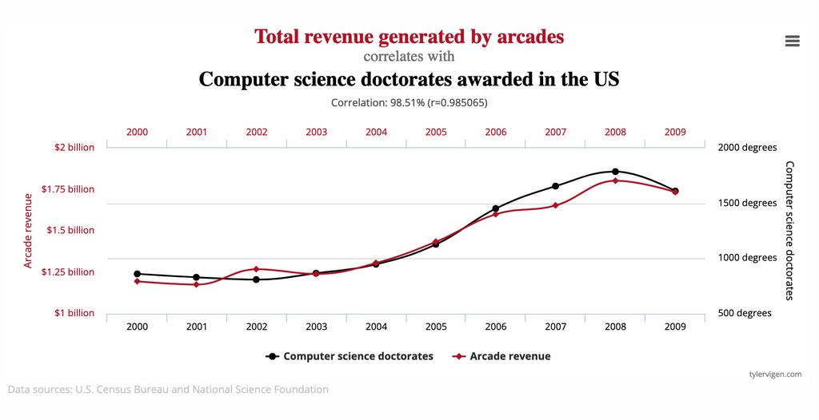

## Counterfactuals

- “…what is not, but could or would have been” (Starr 2019).
- “If a person eats of a particular dish, and dies in consequence, that is, would not have died if he had not eaten it, people would be apt to say that eating of that dish was the source of his death” (Mill 2010).

## Causal Inference as Counterfactuals

- Does AI cause layoffs?
- How many more people *would get a job* had AI never been developed?

[figure not shown]

## Causal Inference as Counterfactuals

- Did Iran conflict/gas prices *cause* Trump’s approval decline?
- Would Trump be more popular *had there not been Iran conflict/higher gas prices*?

[figure not shown]

## A Problem…

- It’s not so easy to do this kind of research!

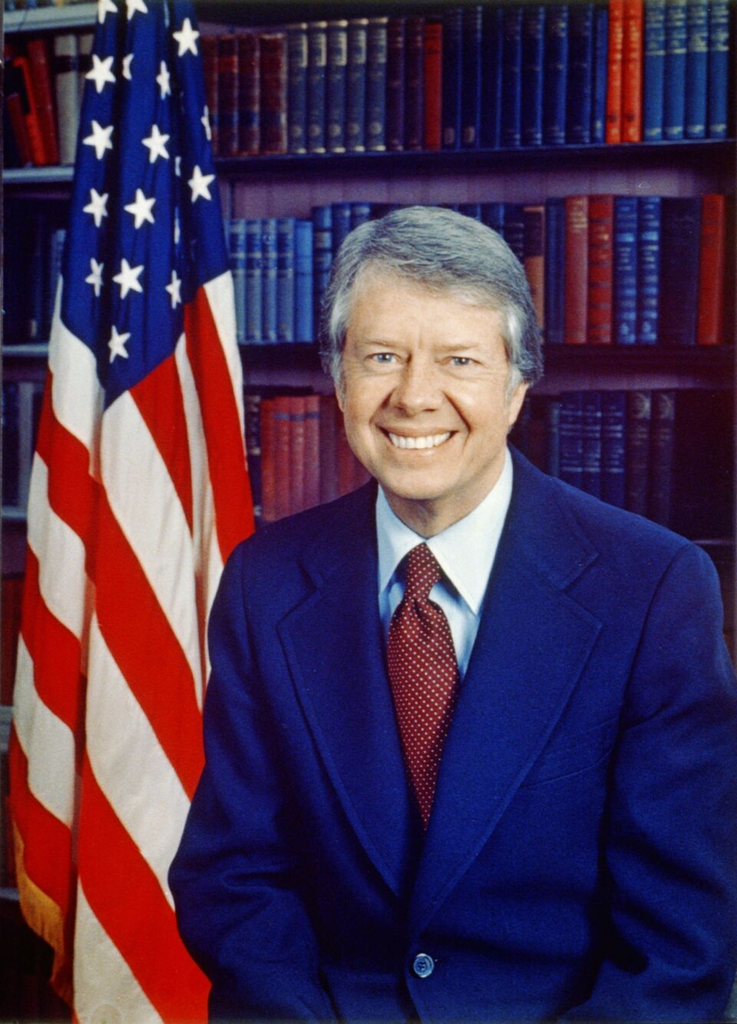

[figure not shown]

[figure not shown]

## Randomized Controlled Trials

- Randomly assign some units to treatment, others to control.
- With enough units, everything else balances across the groups.
- The two groups become good counterfactuals “all else equal.”

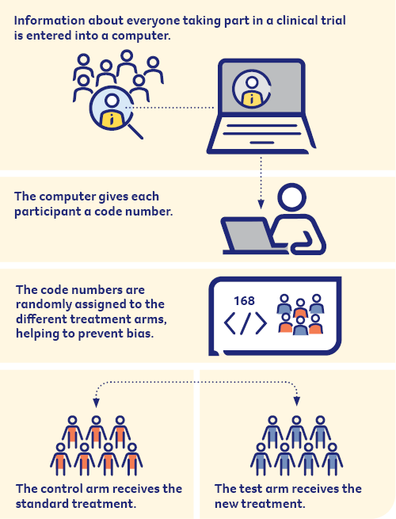

via Cancer Council, NSW

## One Way to Think About the Problem…

- Potential Outcomes Framework (Splawa-Neyman 1932; Rubin 1974).
- Suppose I have a headache.
  - In world 1, I take aspirin and report severity of my headache between 0-10.
  - In world 2, I take no aspirin and report severity between 0-10.
  - Causal effect of aspirin: severity in world 1 minus severity in world 2.

## A New Problem Emerges…

“The fundamental problem of causal inference” (Holland 1986).

[figure not shown]

## Treatment Assignment

- Suppose we have a binary treatment variable:

$$D_i =
\begin{cases}
1 & i \text{ received treatment (e.g., aspirin)} \\
0 & i \text{ received no treatment (e.g., no aspirin)}
\end{cases}$$

- Suppose we have an outcome variable, $Y_i$ (e.g., headache severity). We then have the following potential outcomes, $Y_i^D$:

$$Y_i^D =
\begin{cases}
Y_i^1 & \text{outcome if } i \text{ received treatment} \\
Y_i^0 & \text{outcome if } i \text{ did not receive treatment}
\end{cases}$$

## Observed Outcome

\(Y_i = \)\(D_i Y_i^1\)\(+\)\((1 - D_i) Y_i^0\)

- \(Y_i\) is the outcome we actually observe for unit \(i\).
- When \(D_i = 1\), the treated branch is "switched on."
- When \(D_i = 0\), the control branch is "switched on."

## (Hypothetical) Individual Treatment Effect

$$\delta_i = Y_i^1 - Y_i^0$$

- The individual treatment effect compares the two potential outcomes for the same unit.
- It is hypothetical because we cannot observe both worlds for any one person.

## Average Treatment Effect

$$ATE = \frac{1}{N}\sum_{i=1}^{N}(Y_i^1 - Y_i^0) = \mathbb{E}[Y_i^1] - \mathbb{E}[Y_i^0]$$

- The ATE averages individual treatment effects across units.
- It is still built from both potential outcomes, so it is not directly observable.

## Estimating the ATE

- The target (but it is built from potential outcomes we never fully observe).

$$ATE = \mathbb{E}[Y_i^1] - \mathbb{E}[Y_i^0]$$

- Substitute the outcomes we actually observe in each group.

$$ATE = \mathbb{E}[Y_i^1 \mid D_i = 1] - \mathbb{E}[Y_i^0 \mid D_i = 0]$$

- Valid only when treatment is independent of potential outcomes.

$$(Y^1, Y^0) \perp D$$

## Selection Bias

- Let people *choose* treatment and the groups stop being comparable.
- A naive comparison confuses the effect of treatment with who selected into it.
- This is selection bias, and it lurks in any observational study.
- Randomizing a large sample balances the groups and removes the bias.

## The Fundamental Problem

What world are we in?

What are we estimating?

Four people with headaches (higher Y = worse)

[output not shown]

All potential outcomes: counterfactuals (red, italic) are unobservable

| \(i\) | \(D_i\) | \(Y_i\) | \(Y_i^1\) | \(Y_i^0\) | \(\delta_i\) |
| --- | --- | --- | --- | --- | --- |
| 1 | 1 | 2 | 2 | 5 | −3 |
| 2 | 1 | 4 | 4 | 7 | −3 |
| 3 | 0 | 1 | 0 | 1 | −1 |
| 4 | 0 | 3 | 2 | 3 | −1 |

- **Naive difference in means** \(\mathbb{E}[Y_i \mid D_i=1] - \mathbb{E}[Y_i \mid D_i=0] = \frac{2+4}{2} - \frac{1+3}{2} = +1\)
- **ATE** \(\frac{1}{N}\sum_i \delta_i = \frac{(-3)+(-3)+(-1)+(-1)}{4} = -2\)
- **ATT** (treated only) \(\frac{2+4}{2} - \frac{5+7}{2} = -3\)

Counterfactual · unobservable · via Christopher Lucas

## Comparing Our Estimates

Observed comparison

Naive difference in means

+1

Aspirin looks harmful.

Hidden-world truth

Average treatment effect

−2

Aspirin helps on average.

Among the treated

ATT

−3

It helps the treated most.

## A Few Other Assumptions: SUTVA

- SUTVA: Stable Unit Treatment Value Assumption.
  - Same treatment “dosage.”

[figure not shown]

via Aspirin

## A Few Other Assumptions: SUTVA

- SUTVA: Stable Unit Treatment Value Assumption.
  - Same treatment “dosage.”
  - No externalities or spillovers.

[figure not shown]

## A Few Other Assumptions: SUTVA

- SUTVA: Stable Unit Treatment Value Assumption.
  - Same treatment “dosage.”
  - No externalities or spillovers.
  - No general equilibrium effects.

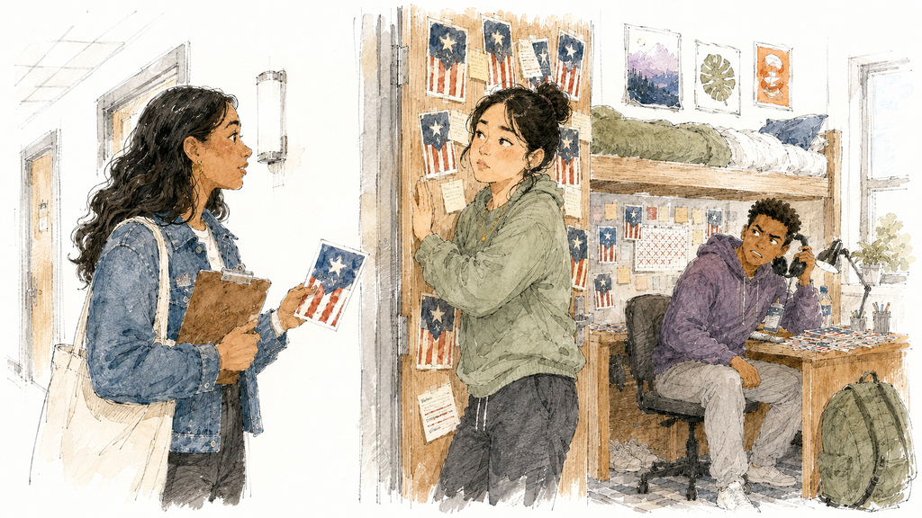

## Taking Stock

Causal inference is about **identification strategy** and **research design**, which depends on **treatment assignment**. Not fancy machine learning methods.

- **Strongest:** treatment is randomized by the researcher.
- **Strong:** treatment is as-if random.
- **Mid:** treatment is as-if random after controls.
- **Weakest:** treatment is self-selected and important confounders remain unmeasured.